# Extreme Gradient Boosting

**Importing necessary Libraries**

```python
import numpy as np
import pandas as pd
```

**Loading the dataset**

```python
data = pd.read_csv('C:/Abhishek/ML-Algorithms/AV/stacking/data_cleaned.csv')
data.head()
```

|  | Survived | Age | Fare | Pclass_1 | Pclass_2 | Pclass_3 | Sex_female | Sex_male | SibSp_0 | SibSp_1 | ... | Parch_0 | Parch_1 | Parch_2 | Parch_3 | Parch_4 | Parch_5 | Parch_6 | Embarked_C | Embarked_Q | Embarked_S |
| --- | --- | --- | --- | --- | --- | --- | --- | --- | --- | --- | --- | --- | --- | --- | --- | --- | --- | --- | --- | --- | --- |
| 0 | 0 | 22.0 | 7.2500 | 0 | 0 | 1 | 0 | 1 | 0 | 1 | ... | 1 | 0 | 0 | 0 | 0 | 0 | 0 | 0 | 0 | 1 |
| 1 | 1 | 38.0 | 71.2833 | 1 | 0 | 0 | 1 | 0 | 0 | 1 | ... | 1 | 0 | 0 | 0 | 0 | 0 | 0 | 1 | 0 | 0 |
| 2 | 1 | 26.0 | 7.9250 | 0 | 0 | 1 | 1 | 0 | 1 | 0 | ... | 1 | 0 | 0 | 0 | 0 | 0 | 0 | 0 | 0 | 1 |
| 3 | 1 | 35.0 | 53.1000 | 1 | 0 | 0 | 1 | 0 | 0 | 1 | ... | 1 | 0 | 0 | 0 | 0 | 0 | 0 | 0 | 0 | 1 |
| 4 | 0 | 35.0 | 8.0500 | 0 | 0 | 1 | 0 | 1 | 1 | 0 | ... | 1 | 0 | 0 | 0 | 0 | 0 | 0 | 0 | 0 | 1 |

5 rows × 25 columns

**Separating Dependent & the Independent Variables**

```python
x = data.drop(['Survived'], axis = 1)
y = data['Survived']
```

**Creating the train test split**

```python
from sklearn.model_selection import train_test_split
```

```python
#divide into train test sets

train_x,test_x,train_y,test_y = train_test_split(x,y,random_state = 101,stratify = y)
```

**Install XGBoost**

Use the following command in terminal or command prompt

- pip install xgboost
- conda install -c anaconda py-xgboost

```python
# Importing XGBM Classifier
from xgboost import XGBClassifier
```

```python
#creating an Extreme Grading boosting instance
clf = XGBClassifier(random_state = 96)
```

```python
#training the model

clf.fit(train_x,train_y)
```

```
XGBClassifier(base_score=0.5, booster='gbtree', colsample_bylevel=1,
              colsample_bynode=1, colsample_bytree=1, gamma=0, gpu_id=-1,
              importance_type='gain', interaction_constraints='',
              learning_rate=0.300000012, max_delta_step=0, max_depth=6,
              min_child_weight=1, missing=nan, monotone_constraints='()',
              n_estimators=100, n_jobs=0, num_parallel_tree=1,
              objective='binary:logistic', random_state=96, reg_alpha=0,
              reg_lambda=1, scale_pos_weight=1, subsample=1,
              tree_method='exact', validate_parameters=1, verbosity=None)
```

```python
#calculation the score on the training data

clf.score(train_x,train_y)
```

```
0.9775449101796407
```

```python
#calculating score on the test data
clf.score(test_x,test_y)
```

```
0.7623318385650224
```

**Hyperparameter Tuning**

Same as GBDT

1. **n_estimators:** Total number of trees
2. **learning_rate:** This determines the impact of each tree on the final column
3. **random_state:** The random number seed so that the random number are generated everytime.
4. **max_depth:** Maximum depth to which a tree can grow(stopping criterion).
5. **subsample:** The fraction of observations to be selected for each tree.Selection is done by random sampling.
6. **objective:** Defines Loss Function.
7. **colsample_bylevel:** Random feature selection at levels
8. **colsample_bytree:** Random feature selection at tree

```
Accuracy: 76.23%
```

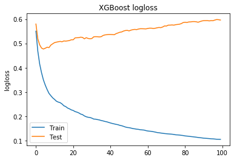

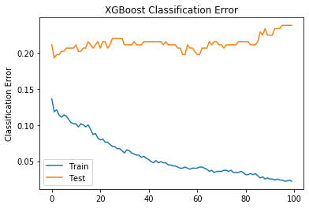

```python
from matplotlib import pyplot
from sklearn.metrics import accuracy_score

#fit model no training data

eval_set = [(train_x,train_y), (test_x,test_y)]
eval_metric = ["logloss","error"]
clf.fit(train_x,train_y, eval_metric=eval_metric, eval_set=eval_set, verbose=True)

#make predictions for test data
y_pred = clf.predict(test_x)
predictions = [round(value) for value in y_pred]

# evaluate predictions
accuracy = accuracy_score(test_y, predictions)
print("Accuracy: %.2f%%" % (accuracy * 100.0))

# retrieve performance metrics
results = clf.evals_result()
epochs = len(results['validation_0']['error'])
x_axis = range(0, epochs)

# plot auc
fig, ax = pyplot.subplots()
ax.plot(x_axis, results['validation_0']['logloss'], label='Train')
ax.plot(x_axis, results['validation_1']['logloss'], label='Test')
ax.legend()
pyplot.ylabel('logloss')
pyplot.title('XGBoost logloss')
pyplot.show()

# plot classification error
fig, ax = pyplot.subplots()
ax.plot(x_axis, results['validation_0']['error'], label='Train')
ax.plot(x_axis, results['validation_1']['error'], label='Test')
ax.legend()
pyplot.ylabel('Classification Error')
pyplot.title('XGBoost Classification Error')
pyplot.show()
```

**Early Stopping with XGBoost**

XGBoost supports early stopping after a fixed number of iterations.

In addition to specifying a metric and test dataset for evaluation each epoch, you must specify a window of the number of epochs over which no improvement is observed. This is specified in the early_stopping_rounds parameter.

For example, we can check for no improvement in logarithmic loss over the 10 epochs as follows:

```python
eval_set = [(test_x, test_y)]
clf.fit(train_x,train_y, early_stopping_rounds=10, eval_metric="logloss", eval_set=eval_set, verbose=True)
```

[output not shown]

[output not shown]

```python
y_pred = clf.predict(test_x)
predictions = [round(value) for value in y_pred]
# evaluate predictions
accuracy = accuracy_score(test_y, predictions)
print("Accuracy: %.2f%%" % (accuracy * 100.0))
```

```
Accuracy: 79.82%
```

**Regularisation**

1. **gamma :** Minimum reduction in loss at every split
2. **Reg_alpha :** Makes leaf weights 0
3. **Reg_lambda :** Decreases leaf weights more smoothly

```python
#training the model

clf = XGBClassifier(gamma = 0.5,random_state = 96)

clf.fit(train_x,train_y)
```

```
XGBClassifier(base_score=0.5, booster='gbtree', colsample_bylevel=1,
              colsample_bynode=1, colsample_bytree=1, gamma=0.5, gpu_id=-1,
              importance_type='gain', interaction_constraints='',
              learning_rate=0.300000012, max_delta_step=0, max_depth=6,
              min_child_weight=1, missing=nan, monotone_constraints='()',
              n_estimators=100, n_jobs=0, num_parallel_tree=1,
              objective='binary:logistic', random_state=96, reg_alpha=0,
              reg_lambda=1, scale_pos_weight=1, subsample=1,
              tree_method='exact', validate_parameters=1, verbosity=None)
```

```python
#calculating score on the test data
clf.score(test_x,test_y)
```

```
0.8071748878923767
```